# Studentenonderzoek

Leon F.A. Wetzel

26 januari 2018

# 1 Over het onderzoek

Het studentenonderzoek vond plaats tussen 14 november en 24 november 2017. Het onderzoek is uitgevoerd door Leon Wetzel in opdracht van het bestuur van studievereniging Real*Time*. Real*Time* is de studievereniging voor de studie HBO-ICT aan de Hanzehogeschool Groningen. De studie valt onder het Instituut voor Communicatie, Media & IT.

Centraal staat de volgende onderzoeksvraag:

*Wat vindt de student van studievereniging RealTime?*

Deze onderzoeksvraag wordt mede beantwoord door onder andere te kijken naar de volgende deelvragen:

1. *Voelen studenten zich welkom bij studievereniging RealTime?*
2. *Wat willen studenten (anders) zien bij studievereniging RealTime?*
3. *Wat ervaren studenten als positief bij RealTime?*
4. *Wat ervaren studenten als negatief bij RealTime?*

Tijdens het onderzoek werd ook gekeken naar de wens vanuit studenten voor bijlessen. Real*Time* biedt sinds het voorjaar van 2017 bijlessen aan onder de naam Study Support. Ook zijn er vragen gesteld over de verenigingswebsite en over de evenementen van de vereniging. De resultaten van de online vragenlijst zijn verwerkt in R (R Core Team, 2016).

- Een $p$-waarde is de statistische berekening die aangeeft hoe groot de kans is dat per toeval een bepaald resultaat tot stand is gekomen als de nullhypothese waar is. Hoe kleiner de $p$-waarde, hoe uitzonderlijker het resultaat is. Standaard geldt dat de kans op toeval lager is dan 5%. Deze standaard wordt gehanteerd in dit onderzoek, want de $a$-waarde is overal 0,05. Als de $p$-waarde lager is dan de $a$-waarde ($p < a$), dan geldt significantie.
- De Mann-Whitney U test en de Wilcoxon rank sum test zijn hetzelfde.
- Bij enkele vragen is de 5-puntslikertschaal gebruikt om gegevens te verzamelen en om te behandelen op intervalmeetniveau (McLeod, 2008; Wieling, 2017). 1 staat voor *Helemaal niet eens* en 5 staat voor *Helemaal eens*.

## 1.1 De studenten

**46** studenten hebben de digitale vragenlijst ingevuld. Van deze studenten studeren **16** Software Engineering (SE), **20** Network & Security Engineering (NSE) en **10** Business IT & Management (BITM).

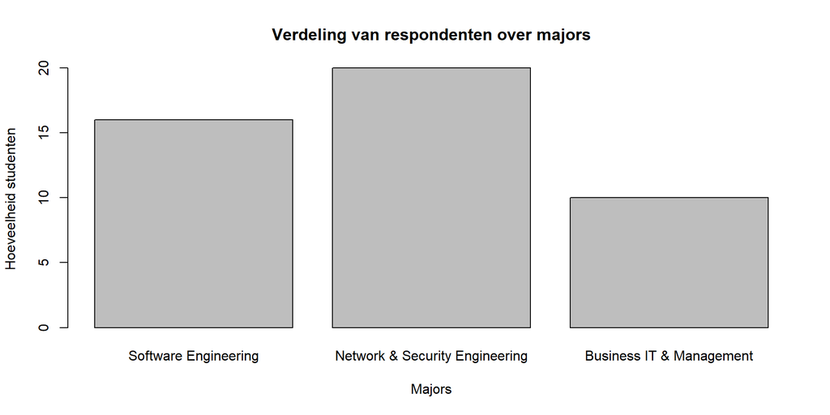

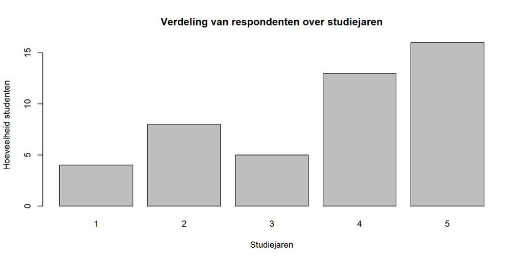

Om uitspraken te doen over de populatie - de studenten van HBO-ICT -, wordt gebruik gemaakt van de data van het stafbureau Financieel Economische Zaken van de Hanzehogeschool Groningen (Scholten, 2017). De totale populatie bestaat uit ongeveer **1024** ingeschreven studenten, inclusief de deeltijdvariant (waarvan $N$=**104**). De deeltijdstudenten vallen buiten de scope van het onderzoek. Voor de voltijd gelden dat er **40** vrouwelijke studenten zijn en dat er **880** mannelijke studenten zijn.

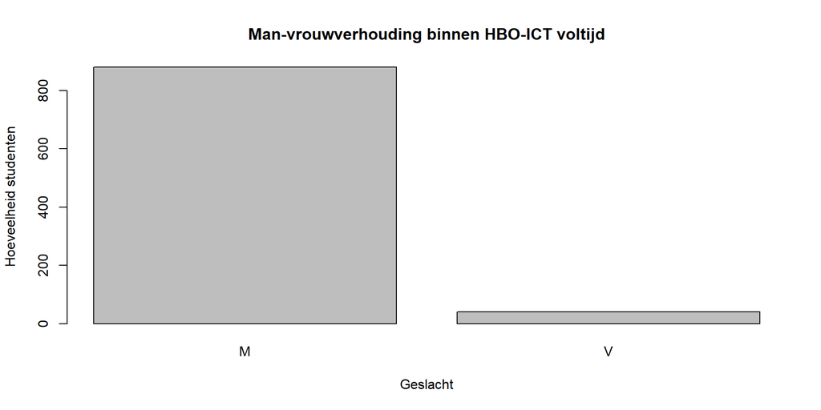

HBO-ICT kende ook een internationale instroom van studenten. Omdat de major Business IT & Management geen internationale instroom meer kent, zijn internationale studenten buiten de scope van het onderzoek gelaten. Hieronder is de verdeling van de nationaliteiten op HBO-ICT voltijd te zien.

```
##
## Bosnie-Herzegovina          Bulgaarse            Chinese
##                  0                  3                  2
##             Duitse              Finse             Franse
##                  1                  1                  1
##              India         Italiaanse        Nederlandse
##                  1                  1                895
##         Oekraiense           Onbekend          Portugese
##                  3                  2                  1
##          Roemeense          Russische          Slowaakse
##                  2                  1                  1
##         Statenloos           Syrische         Vietnamese
##                  0                  4                  1
```

## 1.2 Ledenverdeling

De 46 studenten zijn onder te verdelen in **33** leden en **13** niet-leden.

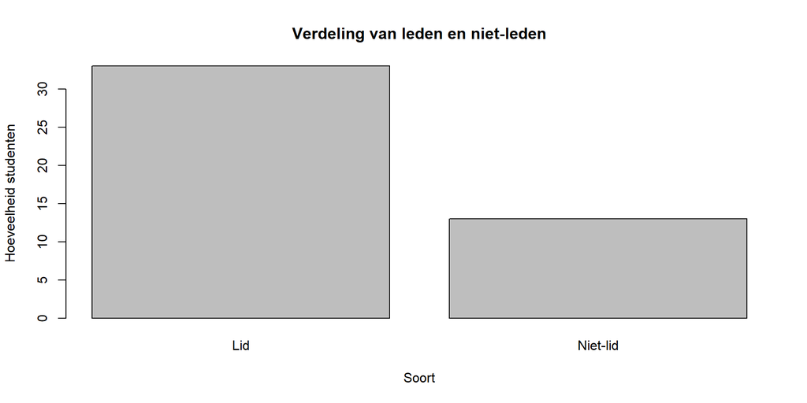

# 2 Activiteiten

In dit hoofdstuk staan de activiteiten van de vereniging centraal. Er wordt gekeken naar de bekendheid van de activiteiten bij studenten en naar welke activiteiten studenten willen gaan.

## 2.1 Bekendheid van activiteiten

De activiteiten van Real*Time* worden op verschillende manieren gepromoot. Zo hangen er in het Instituut voor Communicatie, Media & IT posters voor diverse activiteiten, worden activiteiten gedeeld op sociale media en de website en vindt promotie ook mond-tot-mond plaats.

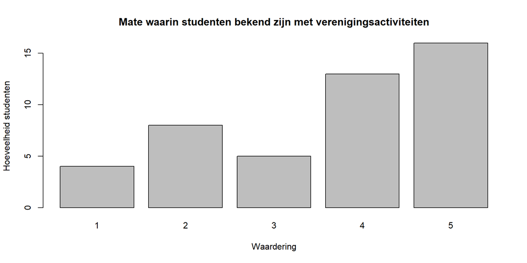

```
##
##  1  2  3  4  5
##  4  8  5 13 16
```

In de bovenstaande figuur is te zien dat de meeste studenten aangeven dat zij wel bekend zijn met de activiteiten van Real*Time* ($N$ = 29, waardering met 4 of 5). 12 studenten gaven aan niet of nauwelijks bekend te zijn met de verenigingsactiviteiten.

## 2.2 Verschillen tussen leden en niet-leden

```
##
##             1  2  3  4  5
##   Lid       0  4  2 12 15
##   Niet-lid  4  4  3  1  1
```

Is er een significant verschil tussen leden en niet-leden als het gaat om de bekendheid van activiteiten? Om die vraag te beantwoorden, willen wij een $t$-test uitvoeren. Om te kijken of we een $t$-test mogen uitvoeren, kijken we eerst of de waarderingen van de respondenten normaalverdeeld zijn. Naast het uitbeelden van de Q-Q plot doen we ook de Shapiro-Wilk test. Als $p < 0.05$, dan zijn de waarderingen van de respondenten **niet** normaalverdeeld.

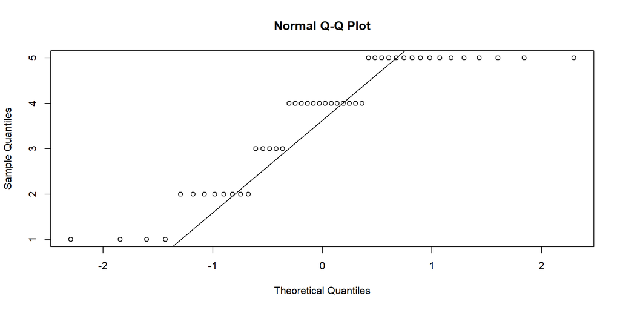

```
##
##  Shapiro-Wilk normality test
##
## data:  quant2
## W = 0.84289, p-value = 2.018e-05
```

We kunnen aannemen dat de waarderingen van de respondenten niet normaalverdeeld zijn. Ter vervanging van de $t$-test dienen we daarom de Mann-Whitney U test uit te voeren.

De hypotheses zijn:

$H_0$: Er is geen significant verschil tussen leden en niet-leden als het gaat om de bekendheid van verenigingsactiviteiten.

$H_a$: Er is een significant verschil tussen leden en niet-leden als het gaat om de bekendheid van verenigingsactiviteiten.

Significantie wordt bereikt als de $p$-waarde lager is dan 0.05, ook wel bekend als $a$. Wat geldt is dus dat $H_a$ geaccepteerd kan worden als $p < a$.

```
##
##  Wilcoxon rank sum test with continuity correction
##
## data:  quant2 by q1
## W = 368.5, p-value = 0.0001019
## alternative hypothesis: true location shift is not equal to 0
```

Hierboven is te zien dat de $p$-waarde uitkomt op 0.0001019, dus geldt $p < a$. Dit betekent dat $H_0$ afgewezen kan worden en dat $H_a$ geaccepteerd kan worden. Er is een significant verschil tussen leden en niet-leden als het gaat om de bekendheid van verenigingsactiviteiten. Significantie werd bereikt onder $a$-level 0,05: W = 368.5, $p$ < 0.0002.

```
##
## Cliff's Delta
##
## delta estimate: 0.7179487 (large)
## 95 percent confidence interval:
##       inf       sup
## 0.3655307 0.8903356
```

De gemiddelde score voor leden is 4,1515152. Voor niet-leden is de gemiddelde score 2,3076923. De effectgrootte is groot (Cliff’s $d$ = 0.7179487).

## 2.3 Wat wil de student?

Studenten is gevraagd naar welke activiteiten zij willen gaan van Real*Time*.

| soort | aantal |
| --- | --- |
| Hackathon | 1 |
| Brainstormsessie | 11 |
| Introductiekamp | 14 |
| Gala | 16 |
| Nieuwjaarsactiviteit | 18 |
| Binnenlandse reis | 19 |
| Kroegcollege | 20 |
| Buitenlandse reis | 21 |
| Kerstdiner | 21 |
| Borrel | 24 |

[output cut: 4 more lines]

Te zien is dat de **gezelligheidsactiviteiten** het meest in trek zijn bij studenten van HBO-ICT, gevolgd door LAN-party’s en bezoeken aan beurzen zoas CeBIT. Studiegerelateerde activiteiten, zoals beursbezoeken en InHouses, komen tweemaal voor in de top vijf van populairste activiteiten. *Hackathons* zaten niet in de vooraf getoonde opties en werd aangegeven door **1** student.

## 2.4 Onderwerpen voor workshops en lezingen

De studiecommissie van Real*Time* organiseert maandelijks lezingen en workshops over ICT-gerelateerde onderwerpen. Elk jaar wordt door de commissie of het bestuur gepeild wat studenten en personeelsleden interessante onderwerpen zouden vinden die behandeld zouden kunnen worden.

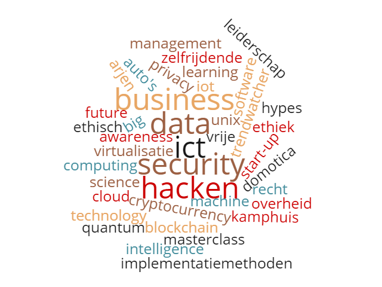

De populairste onderwerpen zijn **Security** (7),**Cryptocurrency** (4), **Blockchain** (4) en **Kunstmatige Intelligentie (AI)** (3). Ook **Big Data** (2), **Domotica** (2), **Machine Learning** (2) en **Privacy** (2) staan in de top 5 verder.

# 3 Study Support

Study Support is de naam waaronder bijlessen en tentamenvoorbereidingen vallen. Sinds voorjaar 2017 experimenteert de vereniging met het geven van deze bijlessen voor diverse vakken. Er is Study Support gegeven voor onder andere **Web Programming**, **Databases**, **Object Oriented Programming**, **Mathematics**, **Statistics** en **Research**.

Study Support wordt gepromoot via de sociale media van de vereniging en de website. Ook zijn er posters te vinden binnen de Van DoorenVeste en worden er via het Instituut e-mails verzonden naar studenten.

## 3.1 Bekendheid van Study Support

Hoe bekend is Study Support bij de studenten van HBO-ICT? Onderstaande figuur laat zien dat 40 van de 46 studenten (= 86.96%) Study Support kent.

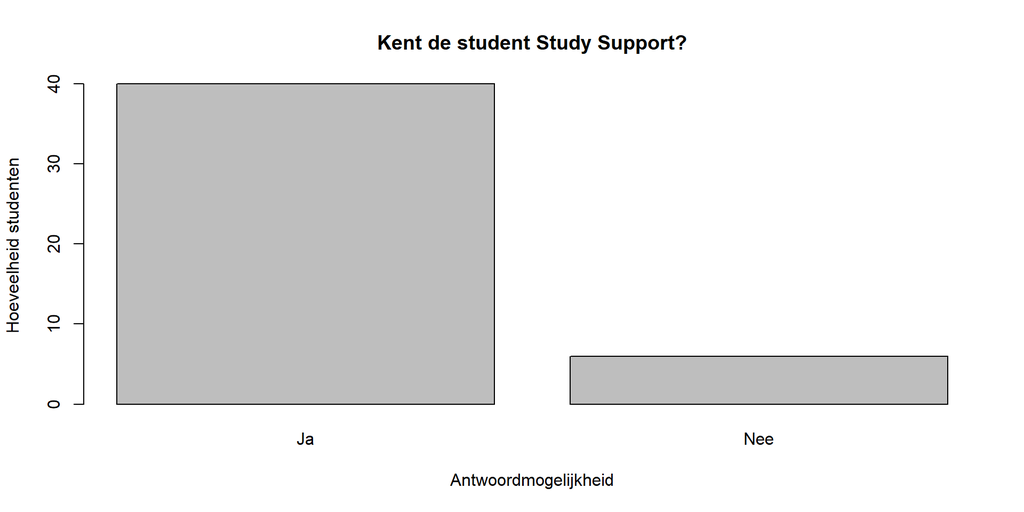

Wie kennen Study Support precies? We gaan eerst kijken naar het studiejaar van de studenten.

```
##
##        1  2  3  4  5
##   Ja   2  6  4 13 15
##   Nee  2  2  1  0  1
```

Is er een verschil tussen leden en niet-leden? Het verschil is te klein om er uitspraken over te doen…

```
##
##       Lid Niet-lid
##   Ja   31        9
##   Nee   2        4
```

## 3.2 Vormen van studieondersteuning

Studieondersteuning is er in vele vormen en maten. Waar hebben de studenen van HBO-ICT precies behoefte aan?

| aantal | soort |
| --- | --- |
| 9 | flitscolleges |
| 9 | practicumondersteuning |
| 14 | examenmateriaal |
| 21 | samenvattingen |
| 23 | tentamenvoorbereiding |

Tentamenvoorbereiding - de huidige vorm van Study Support - is het meest in trek bij studenten, gevolgd door samenvattingen en examenmateriaal.

## 3.3 Animo per vak

Voor welke vakken is er vraag naar Study Support?

| aantal | vak |
| --- | --- |
| 1 | business process modeling |
| 1 | english |
| 2 | computer architecture & design |
| 2 | data visualisation |
| 2 | embedded systems |
| 2 | it service management |
| 4 | operating systems |
| 4 | security awareness |
| 4 | web programming |
| 5 | research |

[output cut: 5 more lines]

Hierboven is te zien dat **Wiskunde** de meeste animo geniet, gevolgd door **Statistiek**, **Object Oriented Programming (OOP)** en **Databases**. Het betreft dus voornamelijk eerstejaars vakken.

## 3.4 Geven van bijles

In welke mate hebben studenten interesse in het geven van bijlessen?

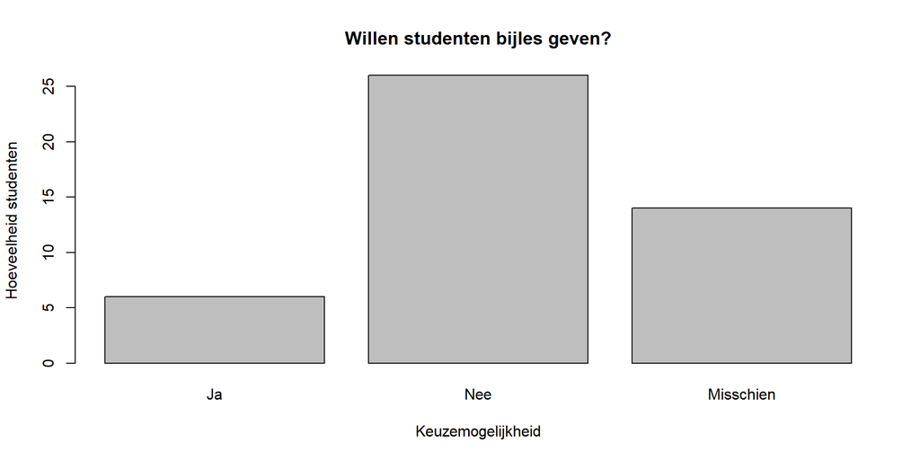

6 studenten geven aan bijles te willen geven. 26 studenten geven aan geen bijles te willen geven. 14 studenten twijfelen of ze bijles willen geven.

# 4 Informatievoorziening

In dit hoofdstuk behandelen we de informatievoorziening naar studenten toe. Sinds dit jaar is er meer studiegerelateerde informatie te vinden op de website. Ook is het bestuur benieuwd wat er eventueel op de website nog dient te komen.

## 4.1 Tentamenrooster

Het tentamenrooster bevat alle tentamens die een student kan of dient te volgen, mits deze is ingeschreven voor het desbetreffende tentamen.

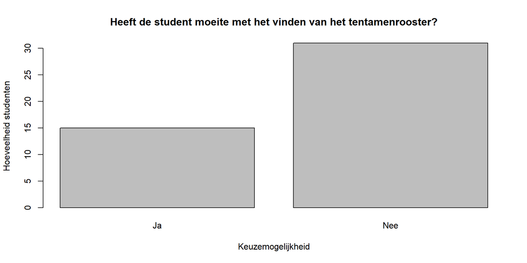

De meeste studenten ($N$ = 31) geven aan geen moeite te hebben met het vinden van het tentamenrooster. 15 studenten geven aan wel moeite te hebben met het vinden van het tentamenrooster.

## 4.2 Studentenstatuut

Het studentenstatuut bevat de belangrijkse rechten en plichten van studenten. Het gaat zowel om rechten en plichten uit allerlei wettelijke regelingen als om regelingen die de Hanzehogeschool Groningen zelf heeft vastgesteld (Hanzehogeschool Groningen, 2017).

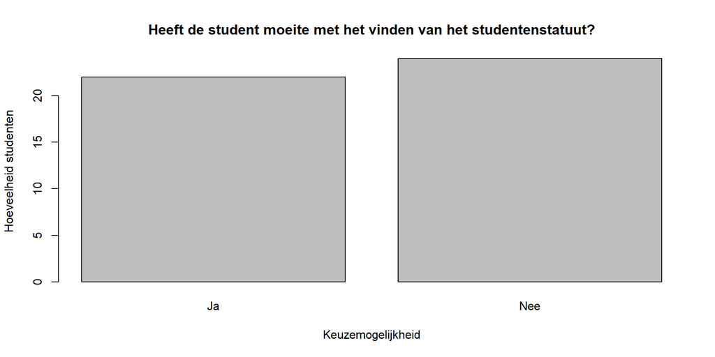

Een krappe meerderheid van de studenten ($N$ = 24) geeft aan geen moeite te hebben met het vinden van het studentenstatuut, versus 22 studenten die aangeven wel moeite te hebben met het vinden van het studentenstatuut.

## 4.3 Onderwijs- en examenregeling

De OER (Onderwijs- en Examenregeling) legt het programma en de tentamens die afgelegd moeten worden vast, evenals de volgorde waarin studieonderdelen gevolgd moeten worden en welke werk- en toetsvorm er per onderdeel wordt gebruikt.

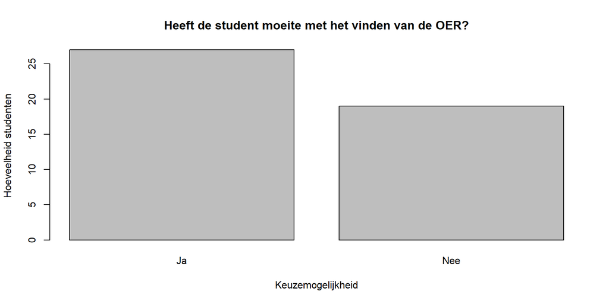

De meeste studenten ($N$ = 27) geven aan moeite te hebben met het vinden van de OER. 19 studenten geven aan geen moeite te hebben met het vinden van de OER.

## 4.4 Real*Time* Agenda

De Real*Time* Agenda is een online openbare agenda waarin de evenementen van de vereniging staan.

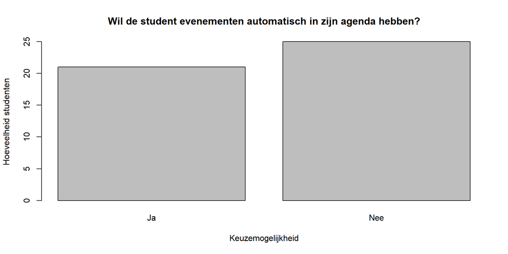

Hieronder is de verdeling tussen leden en niet-leden te zien bij de gestelde vraag.

```
##
##            Ja Nee
##   Lid      18  15
##   Niet-lid  3  10
```

```
##
##                    Ja        Nee
##   Lid      0.39130435 0.32608696
##   Niet-lid 0.06521739 0.21739130
```

Om te kijken of er een verband is tussen lidstatus en de *agendawens*, voeren wij een $\chi^2$-toets uit. We kunnen de $\chi^2$-toets uitvoeren omdat de data willekeurig is verzameld, observaties onfhankelijk zijn gedaan, elke observatie in een categorie is in te delen en omdat de **verwachte** frequente per cel groter of gelijk is aan 5. De hypotheses zijn:

$H_0$: Er is geen verband tussen lidstatus en de wens om verenigingsevenementen automatisch in de agenda te hebben.

$H_a$: Er is een verband tussen lidstatus en de wens om verenigingsevenementen automatisch in de agenda te hebben.

Significantie wordt bereikt onder $a$-level 0,05. De hoeveelheid vrijheidsgraden is 1.

```
##
##  Pearson's Chi-squared test
##
## data:  counts
## X-squared = 3.7223, df = 1, p-value = 0.05369
```

Hierboven is te zien dat $p > a$ geldt. Dit betekent dat er geen significant verband is tussen lidstatus en de wens om verenigingsevenementen automatisch in de agenda te hebben. We kunnen de alternatieve hypothese dus niet accepteren en we handhaven de nullhypothese.

We hebben de $\chi^2$-toets gebruikt om te testen of er een verband is: $\chi^2$(1) = 3.7222777, $p$ = 0.0536911. Wat is de effectgrootte?

```
##                     X^2 df P(> X^2)
## Likelihood Ratio 3.9014  1 0.048247
## Pearson          3.7223  1 0.053691
##
## Phi-Coefficient   : 0.284
## Contingency Coeff.: 0.274
## Cramer's V        : 0.284
```

Cramer’s $V$ is 0.2844628. De effectgrootte - en daarmee de samenhang tussen de twee nominale variabelen - is gemiddeld sterk.

# 5 Stellingen

In dit hoofdstuk gaan we kijken naar wat studenten vinden van Real*Time*. Voelen studenten zich welkom bij de vereniging? Maakt Real*Time* de studetijd leuker? Kijken studenten uit naar de activiteiten van de vereniging? Is Real*Time* behulpzaam? Studenten gaven per stellling aan of zij het (helemaal) eens of oneens waren met een bepaald thema.

## 5.1 Welkom voelen

Studenten is gevraagd of zij zich welkom voelen bij Real*Time*.

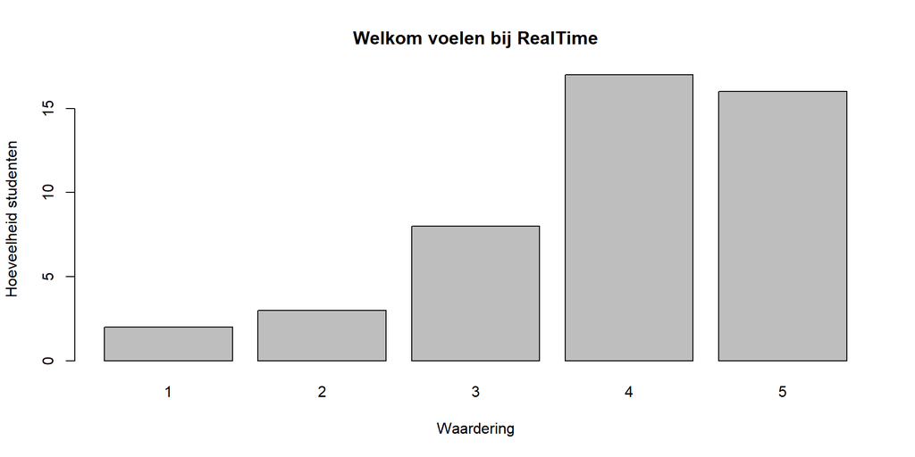

```
##
##  1  2  3  4  5
##  2  3  8 17 16
```

Hierboven is te zien dat de meeste studenten ($N$ = 33) zich welkom voelen bij Real*Time*. Hoe is de verdeling betreft leden en niet-leden?

```
##
##             1  2  3  4  5
##   Lid       0  1  2 14 16
##   Niet-lid  2  2  6  3  0
```

Is er een significant verschil tussen leden en niet-leden als het gaat om het welkom voelen bij Real*Time*? Om die vraag te beantwoorden, voeren wij een $t$-test uit. Om te kijken of we een $t$-test mogen uitvoeren, kijken we eerst of de waarderingen van de respondenten normaalverdeeld zijn. Naast het uitbeelden van de Q-Q plot doen we ook de Shapiro-Wilk test. Als $p < 0.05$, dan zijn de waarderingen van de respondenten **niet** normaalverdeeld.

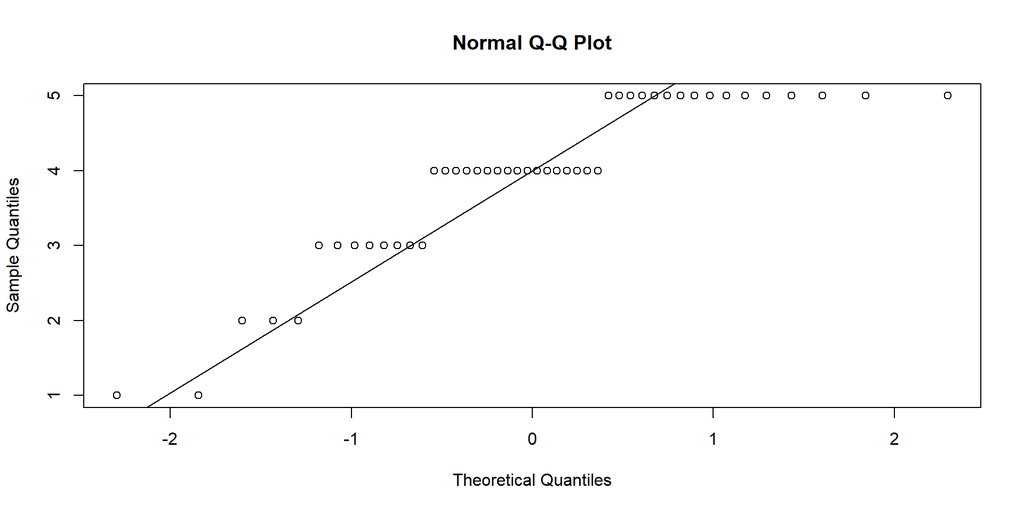

```
##
##  Shapiro-Wilk normality test
##
## data:  quant18
## W = 0.83715, p-value = 1.448e-05
```

We kunnen aannemen dat de waarderingen van de respondenten niet normaalverdeeld zijn. Ter vervanging van de $t$-test dienen we daarom de Mann-Whitney U test uit te voeren.

De hypotheses zijn:

$H_0$: Er is geen significant verschil tussen leden en niet-leden als het gaat om het welkom voelen bij Real*Time*.

$H_a$: Er is een significant verschil tussen leden en niet-leden als het gaat om het welkom voelen bij Real*Time*.

Significantie wordt bereikt als de $p$-waarde lager is dan 0.05, ook wel bekend als $a$. Wat geldt is dus dat $H_a$ geaccepteerd kan worden als $p < a$.

```
##
##  Wilcoxon rank sum test with continuity correction
##
## data:  quant18 by q1
## W = 386, p-value = 1.124e-05
## alternative hypothesis: true location shift is not equal to 0
```

Hierboven is te zien dat de $p$-waarde uitkomt op 1.124008310^{-5}, dus geldt $p < a$. Dit betekent dat $H_0$ afgewezen kan worden en dat $H_a$ geaccepteerd kan worden. Er is een significant verschil tussen leden en niet-leden als het gaat om het welkom voelen bij Real*Time*. Significantie werd bereikt onder $a$-level 0,05: $W$ = 386, $p$ < 0.02.

```
##
## Cliff's Delta
##
## delta estimate: 0.7995338 (large)
## 95 percent confidence interval:
##       inf       sup
## 0.5603452 0.9156310
```

De gemiddelde score voor leden is 4,363636 . Voor niet-leden is de gemiddelde score 2,769231. De effectgrootte is groot (Cliff’s $d$ = 0.7995338).

## 5.2 Leuke studietijd

Studenten is gevraagd of Real*Time* hun studietijd leuker maakt.

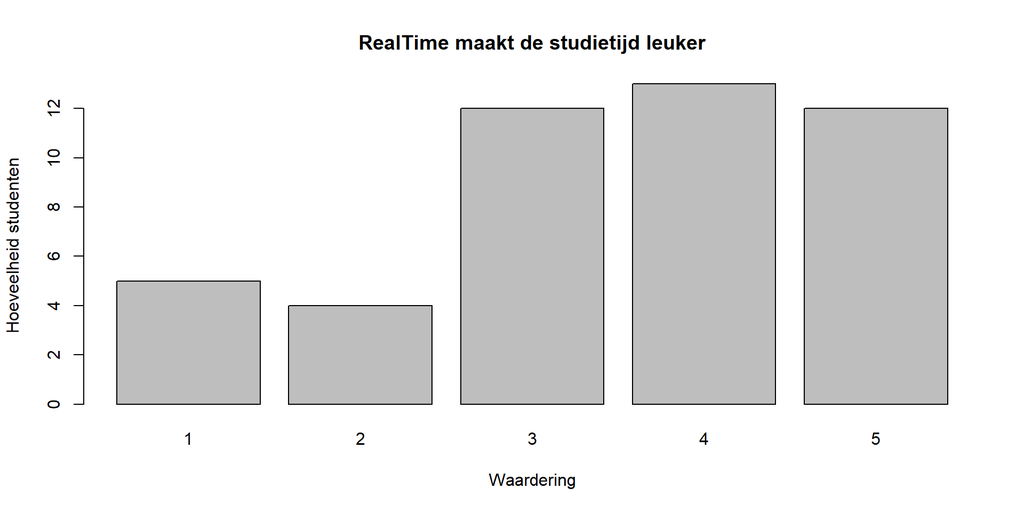

```
##
##  1  2  3  4  5
##  5  4 12 13 12
```

Hierboven is te zien dat de meeste studenten ($N$ = 25) vinden dat Real*Time* hun studietijd leuker maakt. Veel studenten ($N$ = 12) hebben tevens gekozen voor de middenweg; zij kozen de *neutrale* optie. Hoe is de verdeling betreft leden en niet-leden?

```
##
##             1  2  3  4  5
##   Lid       1  0  7 13 12
##   Niet-lid  4  4  5  0  0
```

Is er een significant verschil tussen leden en niet-leden als het gaat om het gevoel dat Real*Time* de studietijd leuker maakt? Om die vraag te beantwoorden, voeren wij een $t$-test uit. Om te kijken of we een $t$-test mogen uitvoeren, kijken we eerst of de waarderingen van de respondenten normaalverdeeld zijn. Naast het uitbeelden van de Q-Q plot doen we ook de Shapiro-Wilk test. Als $p < 0.05$, dan zijn de waarderingen van de respondenten **niet** normaalverdeeld.

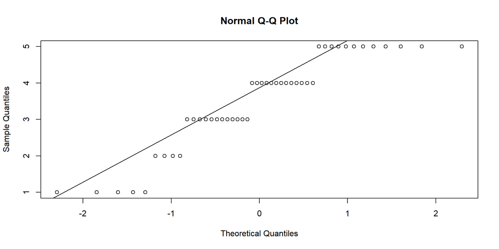

```
##
##  Shapiro-Wilk normality test
##
## data:  quant19
## W = 0.87897, p-value = 0.0001914
```

We kunnen aannemen dat de waarderingen van de respondenten niet normaalverdeeld zijn. Ter vervanging van de $t$-test dienen we daarom de Mann-Whitney U test uit te voeren.

De hypotheses zijn:

$H_0$: Er is geen significant verschil tussen leden en niet-leden als het gaat om het gevoel dat Real*Time* de studietijd leuker maakt.

$H_a$: Er is een significant verschil tussen leden en niet-leden als het gaat om het gevoel dat Real*Time* de studietijd leuker maakt.

Significantie wordt bereikt als de $p$-waarde lager is dan 0.05, ook wel bekend als $a$. Wat geldt is dus dat $H_a$ geaccepteerd kan worden als $p < a$.

```
##
##  Wilcoxon rank sum test with continuity correction
##
## data:  quant19 by q1
## W = 400.5, p-value = 3.063e-06
## alternative hypothesis: true location shift is not equal to 0
```

Hierboven is te zien dat de $p$-waarde uitkomt op 3.0632e-06, dus geldt $p < a$. Dit betekent dat $H_0$ afgewezen kan worden en dat $H_a$ geaccepteerd kan worden. Er is een significant verschil tussen leden en niet-leden als het gaat om het gevoel dat Real*Time* de studietijd leuker maakt. Significantie werd bereikt onder $a$-level 0,05: $W$ = 400.5, $p$ < 0.004.

```
##
## Cliff's Delta
##
## delta estimate: 0.8671329 (large)
## 95 percent confidence interval:
##       inf       sup
## 0.6776156 0.9486504
```

De gemiddelde score voor leden is 4,060606. Voor niet-leden is de gemiddelde score 2,076923. De effectgrootte is groot (Cliff’s $d$ = 0.8671329).

## 5.3 Uitkijken naar verenigingsactiviteiten

Studenten is gevraagd of zij uitkijken naar de activiteiten van de vereniging. Hiermee worden alle activiteiten bedoeld, zoals de gezelligheidsactiviteiten, workshops, bedrijfsbezoeken en lezingen

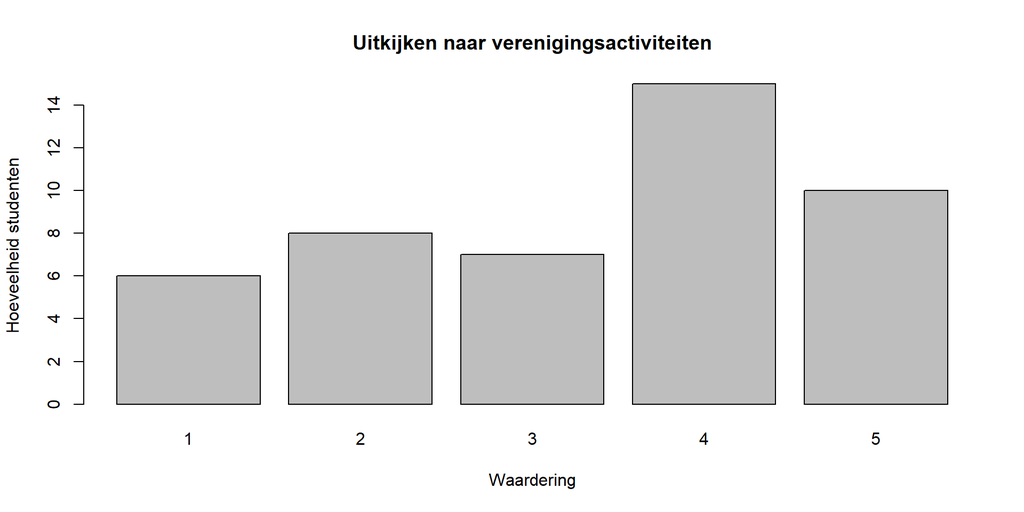

```
##
##  1  2  3  4  5
##  6  8  7 15 10
```

Hierboven is te zien dat de meeste studenten uitkijken naar de activiteiten van de vereniging ($N$ = 25). 14 studenten geven aan niet of nauwelijks uit te kijken naar verenigingsactiviteiten. Hoe is de verdeling betreft leden en niet-leden?

```
##
##             1  2  3  4  5
##   Lid       0  3  5 15 10
##   Niet-lid  6  5  2  0  0
```

Is er een significant verschil tussen leden en niet-leden als het gaat om het uitkijken naar de activiteiten van Real*Time*? Om die vraag te beantwoorden, voeren wij een $t$-test uit. Om te kijken of we een $t$-test mogen uitvoeren, kijken we eerst of de waarderingen van de respondenten normaalverdeeld zijn. Naast het uitbeelden van de Q-Q plot doen we ook de Shapiro-Wilk test. Als $p < 0.05$, dan zijn de waarderingen van de respondenten **niet** normaalverdeeld.

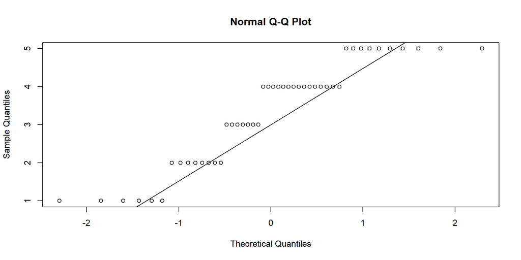

```
##
##  Shapiro-Wilk normality test
##
## data:  quant20
## W = 0.8801, p-value = 0.0002063
```

We kunnen aannemen dat de waarderingen van de respondenten niet normaalverdeeld zijn. Ter vervanging van de $t$-test dienen we daarom de Mann-Whitney U test uit te voeren.

De hypotheses zijn:

$H_0$: Er is geen significant verschil tussen leden en niet-leden als het gaat om het uitkijken naar de activiteiten van Real*Time*.

$H_a$: Er is een significant verschil tussen leden en niet-leden als het gaat om het uitkijken naar de activiteiten van Real*Time*.

Significantie wordt bereikt als de $p$-waarde lager is dan 0.05, ook wel bekend als $a$. Wat geldt is dus dat $H_a$ geaccepteerd kan worden als $p < a$.

```
##
##  Wilcoxon rank sum test with continuity correction
##
## data:  quant20 by q1
## W = 410.5, p-value = 9.225e-07
## alternative hypothesis: true location shift is not equal to 0
```

Hierboven is te zien dat de $p$-waarde uitkomt op 9.22474e-07, dus geldt $p < a$. Dit betekent dat $H_0$ afgewezen kan worden en dat $H_a$ geaccepteerd kan worden. Er is een significant verschil tussen leden en niet-leden als het gaat om het uitkijken naar de activiteiten van Real*Time*. Significantie werd bereikt onder $a$-level 0,05: $W$ = 410.5, $p$ < 0.001.

```
##
## Cliff's Delta
##
## delta estimate: 0.9137529 (large)
## 95 percent confidence interval:
##       inf       sup
## 0.7649235 0.9699606
```

De gemiddelde score voor leden is 3,969697 . Voor niet-leden is de gemiddelde score 1,692308. De effectgrootte is groot (Cliff’s $d$ = 0.9137529).

## 5.4 Kennen van meer bedrijven

Studenten is gevraagd of zij dankzij Real*Time* meer bedrijven leren kennen. Het betreft niet specifiek ICT-bedrijven.

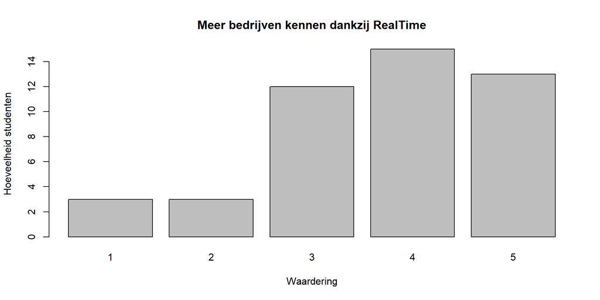

```
##
##  1  2  3  4  5
##  3  3 12 15 13
```

De meeste studenten ($N$ = 28) geven aan dankzij Real*Time* meer bedrijven te leren kennen. Een minderheid ($N$ = 6) geeft aan dat dit niet of nauwelijks het geval is. Hoe is de verdeling betreft leden en niet-leden?

```
##
##             1  2  3  4  5
##   Lid       0  2  7 11 13
##   Niet-lid  3  1  5  4  0
```

Is er een significant verschil tussen leden en niet-leden als het gaat om het kennen van meer bedrijven dankzij Real*Time*? Om die vraag te beantwoorden, voeren wij een $t$-test uit. Om te kijken of we een $t$-test mogen uitvoeren, kijken we eerst of de waarderingen van de respondenten normaalverdeeld zijn. Naast het uitbeelden van de Q-Q plot doen we ook de Shapiro-Wilk test. Als $p < 0.05$, dan zijn de waarderingen van de respondenten **niet** normaalverdeeld.

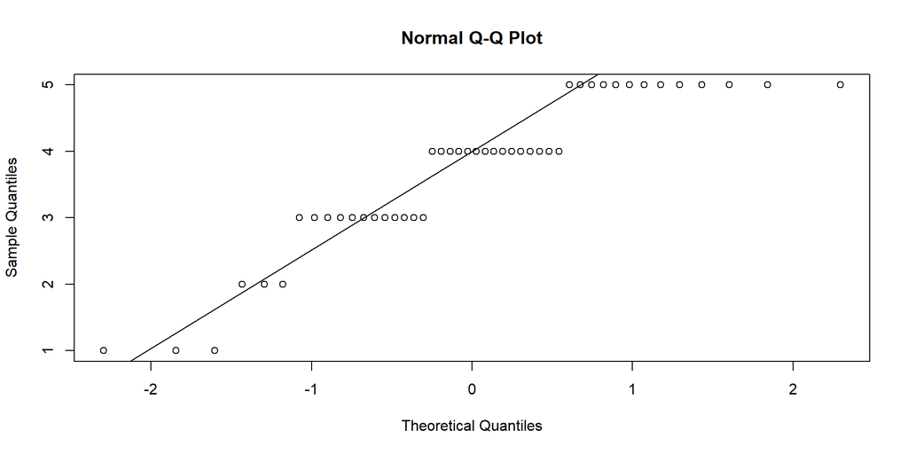

```
##
##  Shapiro-Wilk normality test
##
## data:  quant21
## W = 0.86963, p-value = 0.0001039
```

We kunnen aannemen dat de waarderingen van de respondenten niet normaalverdeeld zijn. Ter vervanging van de $t$-test dienen we daarom de Mann-Whitney U test uit te voeren.

De hypotheses zijn:

$H_0$: Er is geen significant verschil tussen leden en niet-leden als het gaat om het van meer bedrijven dankzij Real*Time*.

$H_a$: Er is een significant verschil tussen leden en niet-leden als het gaat om het van meer bedrijven dankzij Real*Time*.

Significantie wordt bereikt als de $p$-waarde lager is dan 0.05, ook wel bekend als $a$. Wat geldt is dus dat $H_a$ geaccepteerd kan worden als $p < a$.

```
##
##  Wilcoxon rank sum test with continuity correction
##
## data:  quant21 by q1
## W = 342.5, p-value = 0.001219
## alternative hypothesis: true location shift is not equal to 0
```

Hierboven is te zien dat de $p$-waarde uitkomt op 0.0012194, dus geldt $p < a$. Dit betekent dat $H_0$ afgewezen kan worden en dat $H_a$ geaccepteerd kan worden. Er is een significant verschil tussen leden en niet-leden als het gaat om het van meer bedrijven dankzij Real*Time*. Significantie werd bereikt onder $a$-level 0,05: $W$ = 342.5, $p$ < 0.002.

```
##
## Cliff's Delta
##
## delta estimate: 0.5967366 (large)
## 95 percent confidence interval:
##       inf       sup
## 0.2921073 0.7914342
```

De gemiddelde score voor leden is 4,060606. Voor niet-leden is de gemiddelde score 2,769231. De effectgrootte is groot (Cliff’s $d$ = 0.5967366).

## 5.5 Behulpzaamheid

Studenten is gevraagd of zij Real*Time* behulpzaam vinden.

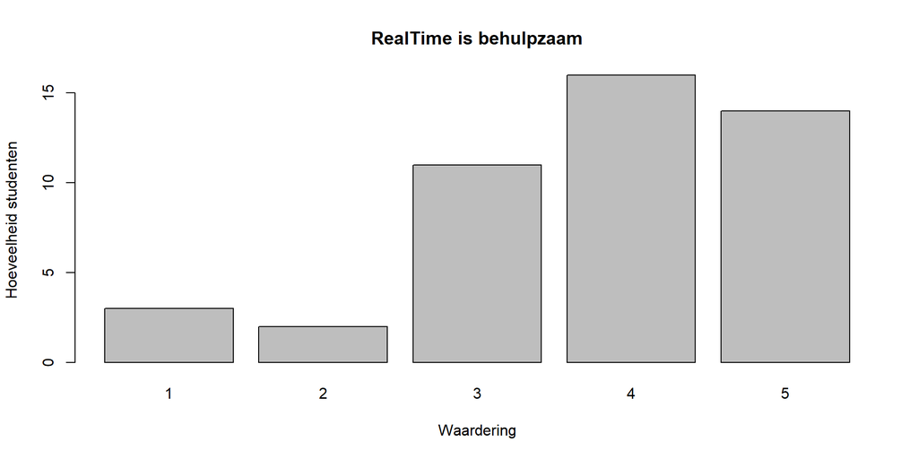

```
##
##  1  2  3  4  5
##  3  2 11 16 14
```

```
##
##             1  2  3  4  5
##   Lid       0  1  6 13 13
##   Niet-lid  3  1  5  3  1
```

Is er een significant verschil tussen leden en niet-leden als het gaat om het behulpzaam vinden van Real*Time*? Om die vraag te beantwoorden, voeren wij een $t$-test uit. Om te kijken of we een $t$-test mogen uitvoeren, kijken we eerst of de waarderingen van de respondenten normaalverdeeld zijn. Naast het uitbeelden van de Q-Q plot doen we ook de Shapiro-Wilk test. Als $p < 0.05$, dan zijn de waarderingen van de respondenten **niet** normaalverdeeld.

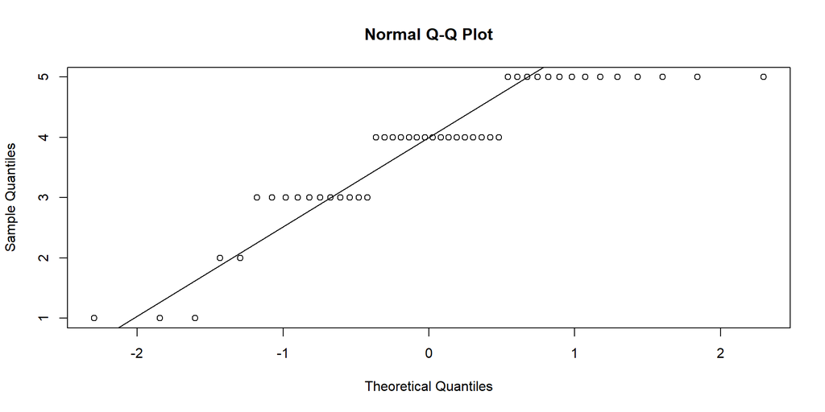

```
##
##  Shapiro-Wilk normality test
##
## data:  quant22
## W = 0.85138, p-value = 3.339e-05
```

We kunnen aannemen dat de waarderingen van de respondenten niet normaalverdeeld zijn. Ter vervanging van de $t$-test dienen we daarom de Mann-Whitney U test uit te voeren.

De hypotheses zijn:

$H_0$: Er is geen significant verschil tussen leden en niet-leden als het gaat om het behulpzaam vinden van Real*Time*.

$H_a$: Er is een significant verschil tussen leden en niet-leden als het gaat om het behulpzaam vinden van Real*Time*.

Significantie wordt bereikt als de $p$-waarde lager is dan 0.05, ook wel bekend als $a$. Wat geldt is dus dat $H_a$ geaccepteerd kan worden als $p < a$.

```
##
##  Wilcoxon rank sum test with continuity correction
##
## data:  quant22 by q1
## W = 341.5, p-value = 0.001263
## alternative hypothesis: true location shift is not equal to 0
```

Hierboven is te zien dat de $p$-waarde uitkomt op 0.0012631, dus geldt $p < a$. Dit betekent dat $H_0$ afgewezen kan worden en dat $H_a$ geaccepteerd kan worden. Er is een significant verschil tussen leden en niet-leden als het gaat om het behulpzaam vinden van Real*Time*. Significantie werd bereikt onder $a$-level 0,05: $W$ = 341.5, $p$ < 0.002.

```
##
## Cliff's Delta
##
## delta estimate: 0.5920746 (large)
## 95 percent confidence interval:
##       inf       sup
## 0.2352316 0.8082595
```

De gemiddelde score voor leden is 4,151515. Voor niet-leden is de gemiddelde score 2,846154. De effectgrootte is groot (Cliff’s $d$ = 0.5920746).

# 6 Algemene opinie

In dit hoofdstuk zoomen we in op wat studenten in het algemeen vinden van Real*Time*. Wat zijn de positieve en negatieve zaken die studenten ervaren? Wat zouden studenten anders willen zien? Wat voor cijfer zouden studenten aan de vereniging geven?

## 6.1 Hoe denken studenten over Real*Time*?

| Toelichting |
| --- |
| Goed dat jullie er zijn! Persoonlijk heb ik niks met studieverenigingen maar er zijn vele andere studenten die gebruik kunnen maken van jullie diensten. |
| Gemiddeld |
| Een leuke groep mensen die je willen helpen als je ergens hulp bij nodig hebt. |
| Leuk |
| een gezellige vereniging waar iedereen een plekje heeft |
| Positief |
| Ik denk dat RealTime een goede aanvulling is op de studie. Vooral het feit dat je meer mensen leert kennen van verschillende studiejaren werkt motiverend. |
| Gezellig |
| Gezellige vereniging die bepaalde zaken erg serieus aanpakt. |
| Een leuke enthousiaste studievereniging waar je altijd langs kan komen voor een praatje! |

[output cut: 11 more lines]

## 6.2 Wat ervaart de student positief aan Real*Time*?

| reden |
| --- |
| Jullie zijn behulpzaam. |
| Leuke activiteiten, en ik weet door RealTime over bedrijfen die intresse hebben in stagaires. |
| Mensen met de zelfde interesses op 1 plek |
| De bijlessen etc |
| Veel leuke mensen, ruimte voor inbreng. |
| Gezelligheid, bonding |
| De sfeer is heel gemoedelijk. Iedereen is enthousiast en behulpzaam. |
| De gastvrijheid |
| Goede activiteiten en professioneel. |
| De leden! Maar ook de activiteiten. Ook al kom je een tijdje niet op activiteiten, dan ben je toch altijd weer welkom :) |

[output cut: 10 more lines]

## 6.3 Wat ervaart de student negatief aan Real*Time*?

| reden |
| --- |
| In jaar een worden er vaak presentaties gegeven over RealTime in de klas. Misschien is het beter om dit buiten de lessen om te doen i.p.v. tijdens een SLB les o.i.d. Mensen die interesse hebben kunnen… |
| Ik heb nog niet veel nut gehad van mijn lidmaatschap, en veel vrienden zijn geen lid, dus doen ze ook niet mee met de activiteiten. |
| Introductiekamp had leuker kunnen zijn |
| Weinig integriteit |
| Te formele sfeer |
| Bestuursdrama |
| Te serieus en bureaucratisch |
| Doordat veel IT'ers gesloten zijn is RealTime vaak een clique van mensen die voor een buitenstaander als arrogant en prominent kan worden ervaren. Dit is niet per sé erg, maar ik vond het moeilijk om … |
| Niet alle bestuursleden zijn sympathiek |
| De bureaucratie |

[output cut: 4 more lines]

## 6.4 Wat zien studenten graag anders bij Real*Time*?

| reden |
| --- |
| Meer redenen geven aan mensen die nog geen lid zijn, om lid te worden. |
| Introductiekamp niet in tenten |
| De formele sfeer kan minder (formulieren voor alles, in pak bij OnTheMOEV) |
| Tot nu toe heb ik nog geen wensen wat dit betreft. |
| Minder bestuursdrama |
| Niks. Ga vooral zo door! |
| Meer dingen door leden on-the-fly georganiseerd |
| Kijk maar eens goed naar FSV Fysiek. |
| Minder woorden, meer actie. |
| Open, chillere vibes. Meer focus op studie en minder albertus light |

[output cut: 5 more lines]

## 6.5 Wat voor cijfer zouden studenten Real*Time* geven?

Studenten konden Real*Time* een cijfer geven dat lag tussen de 1 en de 10. Hieronder zijn de kwartielen, het gemiddelde, het minimum, het maximum, de modus en de mediaan te zien.

```
##    Min. 1st Qu.  Median    Mean 3rd Qu.    Max.
##   1.000   6.250   7.000   6.891   8.000  10.000
```

```
## Mode:  7
```

Hoe ziet de verdeling van de cijfers eruit?

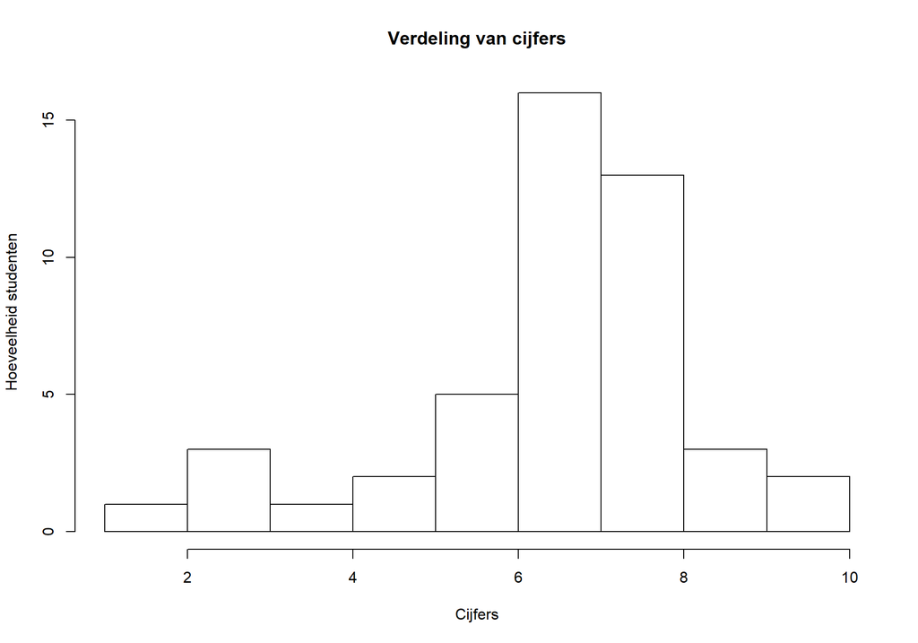

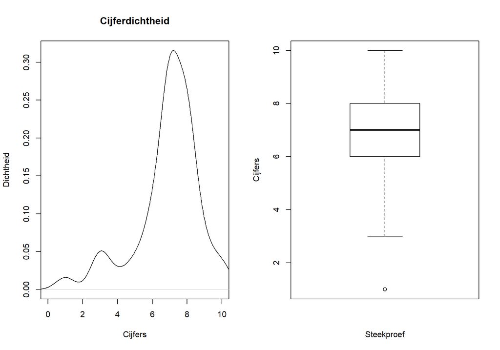

```
##
##             1  3  4  5  6  7  8  9 10
##   Lid       0  0  0  1  3 11 13  3  2
##   Niet-lid  1  3  1  1  2  5  0  0  0
```

Is er een significant verschil tussen de cijfers van leden en de cijfers van niet-leden? Om die vraag te beantwoorden, voeren wij een $t$-test uit. Voordat we de $t$-test kunnen uitvoeren, dienen we te controleren of we voldoen aan de eisen voor de test. We gaan eerst kijken of de data normaalverdeeld is. De hypotheses voor de Shapiro-Wilktest zijn:

$H_0$: Data is normaalverdeeld.

$H_a$: Data is niet normaalverdeeld.

Naast het uitvoeren van de Shapiro-Wilktest kijken we ook naar onderstaande Q-Q-plot.

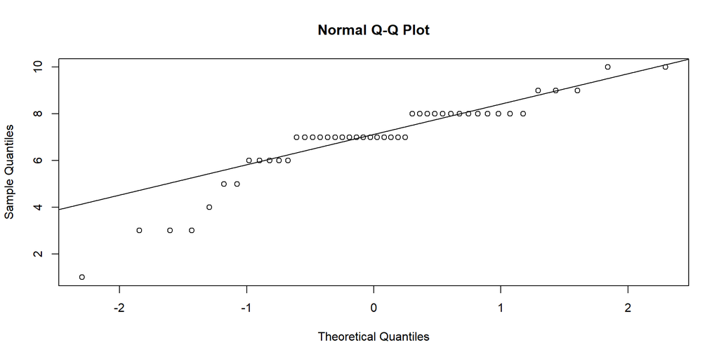

```
##
##  Shapiro-Wilk normality test
##
## data:  dat$q27
## W = 0.87172, p-value = 0.0001188
```

$p < a$, dus geldt dat $H_0$ afgewezen kan worden en dat $H_a$ geaccepteerd kan worden. Het is aannemelijk dat de data niet normaalverdeeld is en dat we daarom de $t$-test niet mogen uitvoeren. In plaats van de $t$-test voeren we daarom de nonparametrische variant uit, namelijk de Mann-Whitney U test (hetzelfde als Wilcoxon’s rank sum test).

De hypotheses zijn:

$H_0$: Er is geen significant verschil tussen de cijfers van leden en de cijfers van niet-leden.

$H_a$: Er is een significant verschil tussen de cijfers van leden en de cijfers van niet-leden.

Significantie wordt bereikt als de $p$-waarde lager is dan 0.05, ook wel bekend als $a$. Wat geldt is dus dat $H_a$ geaccepteerd kan worden als $p < a$. Het aantal vrijheidsgraden is 45.

```
##
##  Wilcoxon rank sum test
##
## data:  quant27 by q1
## W = 376, p-value = 4.557e-05
## alternative hypothesis: true location shift is not equal to 0
```

Hierboven is te zien dat de $p$-waarde uitkomt op 4.557253510^{-5}, dus geldt $p < a$. Dit betekent dat $H_0$ afgewezen kan worden en dat $H_a$ geaccepteerd kan worden. Er is een significant verschil tussen de cijfers van leden en de cijfers van niet-leden. Significantie werd bereikt onder $a$-level 0,05: $W$ = 376, $p$ < 0.004.

```
##
## Cliff's Delta
##
## delta estimate: 0.7529138 (large)
## 95 percent confidence interval:
##       inf       sup
## 0.5039598 0.8863628
```

De mediaan voor de cijfers van leden is 8. De mediaan voor de cijfers van niet-leden is 6. De effectgrootte is groot (Cliff’s $d$ = 0.7529138).

# 7 Conclusie

Het bestuur van S.V. Real*Time* wilt weten hoe studenten over de vereniging denken. De centrale onderzoeksvraag luidt als volgt:

**Wat vindt de student van studievereniging Real*Time*?**

Om deze onderzoeksvraag te beantwoorden, kijken we eerst naar onderstaande deelvragen.

1. *Voelen studenten zich welkom bij studievereniging RealTime?*
2. *Wat willen studenten (anders) zien bij studievereniging RealTime?*
3. *Wat ervaren studenten als positief bij RealTime?*
4. *Wat ervaren studenten als negatief bij RealTime?*

Deze deelvragen zijn te beantwoorden door te kijken naar de informatie in hoofdstukken 5 en 6.

## 7.1 Voelen studenten zich welkom bij Real*Time*?

In paragraaf 1 van hoofdstuk 5 valt te zien dat de meeste studenten ($N$ = 33; 72% van de respondenten) zich welkom voelen bij Real*Time*. Er blijkt een significant verschil te zijn tussen leden en niet-leden als het gaat om de mate waarin zij zich welkom voelen bij de vereniging. De gemiddelde score voor leden is 4,363636 . Voor niet-leden is de gemiddelde score 2,769231.

## 7.2 Wat willen studenten (anders) zien bij Real*Time*?

Respondenten geven aan dat de bureaucratie verminderd moet worden en dat de formele sfeer verminderd moet worden. Wat ook terugkomt is dat er gewerkt moet worden aan het beter werven van leden en dat leden zelf meer moeten kunnen organiseren. Daarnaast geven sommigen aan dat studenten positiever bereikt moeten worden. Enkelingen geven aan dat er meer InHouses bij grotere bedrijven plaats mogen vinden, het introductiekamp niet meer in tenten moet plaatsvinden en dat er meer gefocust moet worden op de studie.

## 7.3 Wat ervaren studenten als positief bij Real*Time*?

Respondenten waarderen de leuke mensen, de gezelligheid, de sfeer en de professionaliteit. De bijlessen worden ook vaak genoemd, evenals de activiteiten die omschreven worden als leuk. De behulpzaamheid komt ook vaak terug.

## 7.4 Wat ervaren studenten als negatief bij Real*Time*?

Enkele respondenten hekelen de bureaucratie binnen de vereniging. Enkelen geven aan dat het introductiekamp leuker kon zijn, er veel presentaties in de klas zijn, er weinig integriteit is en dat het met name voor eerstejaars studenten gesloten aan kan voelen. Een enkeling benoemd ook dat hij veel commercie ervaart en dat hij het gevoel heeft dat Real*Time* constant reclame maakt.

## 7.5 Wat vindt de student van Real*Time*?

In paragraaf 1 van hoofdstuk 6 is te lezen dat de respondenten over het algemeen de vereniging gezellig en leuk vinden. Er is veel waardering voor de professionaliteit en de behulpzaamheid. De reacties zijn over het algemeen positief.

De meeste respondenten zijn in het algemeen positief over Real*Time*. Globaal is telkens te zien dat niet-leden significant lager scoren op waarderingen. Zij geven over het algemeen lagere scores en zijn in de meeste gevallen negatiever over zaken.

## 7.6 Overige bevindingen

- Studenten geven aan dankzij Real*Time* meer bedrijven te leren kennen.
- De meeste studenten hebben moeite met het vinden van de OER.
- Studenten willen bijles voor met name Wiskunde, Statistiek, OOP en Databases.
- Study Support is bekend onder studenten.
- Studenten bezoeken het liefst de gezelligheidsactiviteiten van de vereniging, gevolgd door LAN-party’s, beurzen en InHouses.
- Real*Time* wordt als behulpzaam ervaren.

# Bronvermelding

Hanzehogeschool Groningen. (2017, June). Studentenstatuut. Groningen, Netherlands: Hanzehogeschool Groningen. Retrieved from https://www.hanze.nl/nld/studiekeuze/hanzehogeschool/studentenstatuut

McLeod, S. (2008). Likert scale. Retrieved from https://www.simplypsychology.org/likert-scale.html

R Core Team. (2016). *R: A language and environment for statistical computing*. Vienna, Austria: R Foundation for Statistical Computing. Retrieved from https://www.R-project.org/

Scholten, W. (2017, November). Aantallen studenten. Groningen, Netherlands: Hanzehogeschool Groningen. Retrieved from https://www.hanze.nl/nld/organisatie/stafbureau/financieel-economische-zaken/producten-en-diensten/studentenadministratie/aantallen-studenten

Wieling, M. (2017, April). Descriptive statistics. *Statistiek I*. University of Groningen. Retrieved from http://www.let.rug.nl/~wieling/Statistiek-I/HC2/#15